# Something’s Fishy

From [538 Riddler: Can You Find The Fish In State Names?](https://fivethirtyeight.com/features/somethings-fishy-in-the-state-of-the-riddler/)

> From Mark Bradwin comes a fishy puzzle about state names:

> Ohio is the only state whose name doesn’t share any letters with the word “mackerel.” It’s strange, but it’s true.

> But that isn’t the only pairing of a state and a word you can say that about — it’s not even the only fish! Kentucky has “goldfish” to itself, Montana has “jellyfish” and Delaware has “monkfish,” just to name a few.

> What is the longest “mackerel?” That is, what is the longest word that doesn’t share any letters with exactly one state? (If multiple “mackerels” are tied for being the longest, can you find them all?)

> Extra credit: Which state has the most “mackerels?” That is, which state has the most words for which it is the only state without any letters in common with those words?

> (For both the Riddler and the extra credit, please refer to Friend of the Riddler™ Peter Norvig’s [word list](https://norvig.com/ngrams/word.list).)

## Answers first!

1. The longest mackerels is… well, there are two, at 23 letters: “counterproductivenesses” for Alabama, “hydrochlorofluorocarbon” for Mississippi.
2. Extra credit: Ohio has the most mackerels: 11,342 of them.
3. … and a few fun facts:
   1. the word with the largest number of unique letters shares a letter with every state
   2. there exists a word which shares no letters with all but one state
   3. there are 18 states which have no mackerels.

## Showing the work

### Data capturing, processing, caching

First things first: I’ll grab Peter Norvig’s word list and derive some useful information from it. I don’t want to hammer norvig.com too much during development, so I’ll cache the word list locally.

```r
if (!file.exists("words.csv")) {
  words <- read.table("https://norvig.com/ngrams/word.list", stringsAsFactors = F)
  names(words) <- c("word")
  words$length <- nchar(words$word)
  # For an optimization, I could throw away words shorter than "mackerel", but...
  # I need them for the extra credit question.

  # The words are in alphabetical order; sort by length instead.
  words <- words[order(words$length, decreasing=T),]
  write.table(words, "words.csv")
}
words <- read.table("words.csv", stringsAsFactors=F)

str(words)
```

```
## 'data.frame':    263533 obs. of  2 variables:
##  $ word  : chr  "pneumonoultramicroscopicsilicovolcanoconiosis" "dichlorodiphenyltrichloroethanes" "dichlorodiphenyltrichloroethane" "floccinaucinihilipilifications" ...
##  $ length: int  45 32 31 30 29 29 28 28 27 27 ...
```

Along with all the words, I need all the state names. I made myself a list of the 50 states, all lower case.

```r
states <- read.table("states.csv", stringsAsFactors=F, sep="\n")
names(states) <- c("state")
str(states)
```

```
## 'data.frame':    50 obs. of  1 variable:
##  $ state: chr  "alabama" "alaska" "arizona" "arkansas" ...
```

### Encoding the Codes

I’ll be asking this question: “does word W have any letters in common with state S?”. For example, “mackerel” has no letters in common with “ohio”, but it has letters in common with maine, michigan, montana… and every other state. I’ll take advantage of the fact that repeated letters, and letter order don’t matter - that is, “does ‘mackerel’ have any letters in common with ‘ohio’?” and “does ‘aceklmr’ have any letters in common with ‘hio’?” are really the same question. I’ll encode each word and state as a vector of 26 bits, with ‘1’ meaning “letter is present”. Then I’ll bitwise-AND a word and a state code; iff there are no letters in common, the result is 0. If the compiler is smart, these bitwise operations should be efficient.

Here’s a utility function to encode a string of letters.

```r
# encode each letter as a binary number with only one bit set.
# fortunately there are fewer than 33 letters, so all the encodings will fit in a 32-bit word.
bitmasks <- sapply(1:26, function(x) as.integer(2**(x-1)))
# each word is encoded as a binary number with a bit set to 1 only if a letter is present.
# examples:
#  "a" is encoded as 1
#  "ab" is encoded as 3
# "zebra" is encoded as 0x2020013
# note: encodings are not unique! That is, many words can share the same encoding, like "stars" and "rats"
encode <- function(word) {
  # list of characters
  chs <- strsplit(word, "")[[1]]
  # eliminate dups, so we can sum instead of OR
  chs <- unique(chs)
  # convert to letter position
  indices <- match(chs, letters)
  # whitespace yields NA; drop those
  indices <- indices[!is.na(indices)]
  # index to onehot bit mask
  onehots <- bitmasks[indices]
  # they're unique, so OR them by adding
  code <- sum(onehots)
  # a sum of integers might exceed integer range - but I know it won't. Cast to int for efficiency.
  return(as.integer(code))
}
```

Now I’ll augment my data sets with encodings for each word and state. With around 260,000 words in the word list, I worried that this step would be very time consuming, but it only takes a few seconds.

```r
words$code <- sapply(words$word, encode)
states$code <- sapply(states$state, encode)
```

Here’s a function that takes a candidate word code, and returns the number of states that the word has 0 letters in common with. If that number is 1, meaning the word is a mackerel, the function returns the state name for the word also. In case you only care about state names for mackerels, there’s a helper function that just returns mackerel state names or NA.

```r
mackerel_query <- function(code) {
  noshares <- states[bitwAnd(code, states$code) == 0,]
  state <- NA
  n <- nrow(noshares)
  if (n == 1) {
    state <- noshares[1, "state"]
  }
  return(list(state, n))
}

is_mackerel <- function(code) {
  results <- mackerel_query(code)
  return(results[[1]])
}
```

### Sanity Checks

Is “mackerel” a mackerel? If so, for which state?

```r
test_mackerel <- function(word) {
  code <- encode(word)
  results <- mackerel_query(code)
  if (is.na(results[[1]])) {
    print(sprintf("'%s' is not a mackerel: has no letters in common with %d states.", word, results[[2]]), quote=F)
  } else {
    print(sprintf("'%s' is a mackerel for %s", word, results[[1]]), quote=F)
  }
}
test_mackerel("mackerel")
```

```
## [1] 'mackerel' is a mackerel for ohio
```

And how about a non-mackerel? It’s pretty easy to find a word with no letters in common with more than one state. How about “the”?

```r
test_mackerel("the")
```

```
## [1] 'the' is not a mackerel: has no letters in common with 18 states.
```

I have three other examples, so I’ll try them too:

```r
test_mackerel("goldfish")
```

```
## [1] 'goldfish' is a mackerel for kentucky
```

```r
test_mackerel("jellyfish")
```

```
## [1] 'jellyfish' is a mackerel for montana
```

```r
test_mackerel("monkfish")
```

```
## [1] 'monkfish' is a mackerel for delaware
```

Sanity achieved!

### Find Some Longest Mackerels

I’ll start with the longest word(s), and work my way down the list, stopping at the first mackerels. I won’t need to search below the length of “jellyfish”, since that’s a known mackerel.

```r
for (len in max(words$length):nchar("jellyfish")) {
  longwords <- words[words$length == len,]
  if (nrow(longwords) > 0) {
    longwords$mackerel_state <- sapply(longwords$code, is_mackerel)
    mackerels <- longwords[!is.na(longwords$mackerel_state), ]
    if (nrow(mackerels) > 0) {
      print(mackerels)
      break;
    }
  }
}
```

```
##                           word length     code mackerel_state
## 48392  counterproductivenesses     23  4120860        alabama
## 106218 hydrochlorofluorocarbon     23 17983663    mississippi
```

That’s it, two 23-letter words tie for first place.

### Extra credit

Which state has the most mackerels? To answer this I’m going to find all the mackerels among the 260,000 words, keeping track of each mackerel’s state; then I’ll find the state that appears the most times. Running is_mackerel on each word does take a while - an optimization could take advantage of the fact that many words share the same code, and only process unique codes.

```r
words$mackerel_state <- sapply(words$code, is_mackerel)
mackerels <- words[!is.na(words$mackerel_state), ]
```

Now I just have to add up the number of times each state is a mackerel state, for all the words.

```r
mackerel_count <- mackerels %>% group_by(mackerel_state) %>% summarize(mackerels=n())
mackerel_count <- mackerel_count[order(mackerel_count$mackerels, decreasing=T),]
names(mackerel_count) <- c("state", "mackerels")
head(mackerel_count, n=10)
```

| state | mackerels |
| --- | --- |
| ohio | 11342 |
| alabama | 8274 |
| utah | 6619 |
| mississippi | 4863 |
| hawaii | 1763 |
| kentucky | 1580 |
| wyoming | 1364 |
| tennessee | 1339 |
| alaska | 1261 |
| nevada | 1229 |

Looks like Ohio is the mackereliest; with only 3 unique letters, maybe it’s not surprising.

### A Few Misguided Plots

There’s quite a range of mackerel counts among the states, so I’ll put them on a log scale.

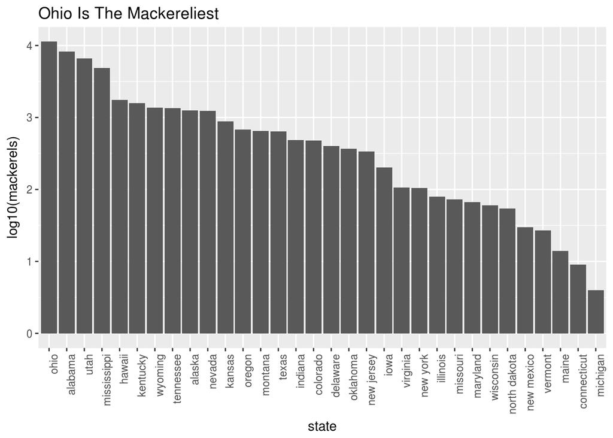

```r
mackerel_count$fstate <- factor(mackerel_count$state, levels=mackerel_count$state[order(mackerel_count$mackerels, decreasing=T)])
ggplot(mackerel_count, aes(x=fstate, y=log10(mackerels))) +
  xlab("state") +
  ggtitle("Ohio Is The Mackereliest") +
  geom_bar(stat="identity") +
  theme(axis.text.x = element_text(angle = 90, hjust = 1))
```

```r
no_mackerels <- states[!states$state %in% mackerel_count$state,]
```

Not all states appear in this graph! Here are the 18 states which have no mackerels:

```r
print(no_mackerels$state)
```

```
##  [1] "arizona"        "arkansas"       "california"     "florida"
##  [5] "georgia"        "idaho"          "louisiana"      "massachusetts"
##  [9] "minnesota"      "nebraska"       "new hampshire"  "north carolina"
## [13] "pennsylvania"   "rhode island"   "south carolina" "south dakota"
## [17] "washington"     "west virginia"
```

This seems like a terrible application for a map graph (choropleth), since the data has nothing to do with geographical position. Let’s do it! I’m giving Ohio a tasteful red border, to help it stand out from the crowd.

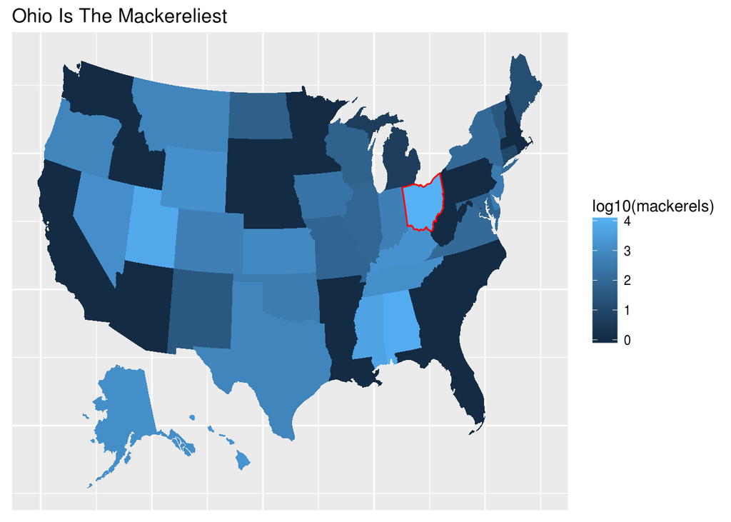

```r
map <- usmap::us_map()
# change the 'full' column to lowercase 'state'
map$state <- tolower(map$full)
map <- subset(map, select=-full)
map <- subset(map, select=-abbr)
map <- left_join(map, mackerel_count, by="state")
# states with no mackerels were not present in mackerel_count, so
# are NA in the joined dataframe. Set those NAs to 1 (not 0, because
# I'm going to plot on a log scale).
map$mackerels <- ifelse(is.na(map$mackerels), 1, map$mackerels)
ggplot() +
  geom_polygon(data=map, aes(x=x, y=y, group=group, fill=log10(mackerels))) +
  geom_polygon(data=map[map$state == "ohio",], aes(x=x, y=y, group=group, fill=log10(mackerels)), color="red") +
  ggtitle("Ohio Is The Mackereliest") +
  theme(
    axis.title.x=element_blank(),
    axis.text.x=element_blank(),
    axis.ticks.x=element_blank(),
    axis.title.y=element_blank(),
    axis.text.y=element_blank(),
    axis.ticks.y=element_blank()
  )
```

### A Generalization of Mackerels

A mackerel is a word for which exactly 1 state shares 0 letters. Of the 263533 words in Peter Norvig’s list, only 45385 are mackerels. What about the rest? There might be some words which share 0 letters with no states, or 3 states, or 18 states (as I saw above with “the”). I’ll declare a word’s “M” number to be the number of non-sharing states. For “mackerel”, M is 1; for “the” M is 18.

I’ll add the M value to each word in my dictionary:

```r
words$M <- sapply(words$code, function(c) mackerel_query(c)[[2]])
```

It might also be interesting to look at the number of unique letters in a word. I’ll group the words into bins which have the same values for these three traits: unique letter count, word length, M. I’ll plot the word bins in a bubble chart, with bubble size indicating “n”, the number of words in the bin.

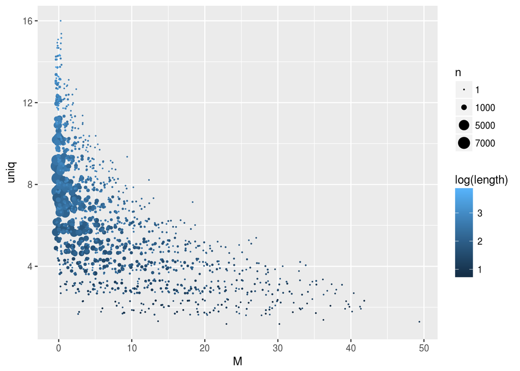

```r
words$uniq <- sapply(words$word, function(w) { chs <- strsplit(w, "")[[1]] ; length(unique(chs))} )

# group all the words into bins of same (uniq, M, Length);
# count the size of each bin and put that in new column 'n';
# sort by decreasing n, so small bubbles don't hide behind big bubbles in the plot.
w2 <- words %>% group_by(uniq, M, length) %>% summarize(n=n()) %>% arrange(desc(n))
ggplot(w2, aes(M, uniq, size=n, color=log(length))) +
  geom_point(alpha=1.0, position="jitter") +
  scale_size(range = c(.1, 5), breaks=c(1, 1000, 5000, 7000))
```

Interpretation: it’s messy! But I can see that low M numbers - 0 to 3 or so - cluster where words are long, and unique letters in a word are around 6 to 9.

There is an outlier with 16 unique letters (position=“jitter” might place the point not-quite-at uniq=16).

```r
words[words$uniq == max(words$uniq),]
```

|  | word | length | code | mackerel_state | M | uniq |
| --- | --- | --- | --- | --- | --- | --- |
| 167156 | phenylthiocarbamides | 20 | 17758623 | NA | 0 | 16 |

“phenylthiocarbamides” shares a letter with every state!

On the other end of the graph, there’s a word with M value near 50.

```r
maximalM <- words[words$M == max(words$M), "word"]
maximalM
```

```
## [1] "zzz"
```

I didn’t know ‘zzz’ was a word! M is 49 - meaning ‘zzz’ has 0 letters in common with 49 out of 50 states. Which state does it have a letter in common with?

```r
letter <- unique(strsplit(maximalM, "")[[1]])
for (state in states$state) {
  letters <- strsplit(state, "")[[1]]
  if (!is.na(any(match(letters, letter)))) {
    print(sprintf("%s is the only state with a '%s'", state, letter))
    break;
  }
}
```

```
## [1] "arizona is the only state with a 'z'"
```

Source code is [here](https://github.com/aaronferrucci/fishstates)

Github hosting is [here](https://aaronferrucci.github.io/fishstates/)